# Ejercicio de box counting

*Aprendizaje máquina II*

*Curso 2023-2024*

Authors:

- Rubén Castillo Carrasco

- Manuel Rubio Martínez

# Box-counting in three dimensional numpy arrays.

Description from [wikipedia](https://en.wikipedia.org/wiki/Fractal_dimension)

> In mathematics, more specifically in fractal geometry, a fractal dimension is a ratio providing a statistical index of complexity comparing how detail in a pattern (strictly speaking, a fractal pattern) changes with the scale at which it is measured. It has also been characterized as a measure of the space-filling capacity of a pattern that tells how a fractal scales differently from the space it is embedded in; a fractal dimension does not have to be an integer.

Here we offer a function that calculates the fractal dimension of an object embedded in three dimensional space using the boxcounting method, also known as the [Minkowski-Bouligand](https://en.wikipedia.org/wiki/Minkowski%E2%80%93Bouligand_dimension) dimension.

### Usage

Simple example, measuring a box in 3D space.

```
Fractal Dimension of the box: 2.819136582593933
```

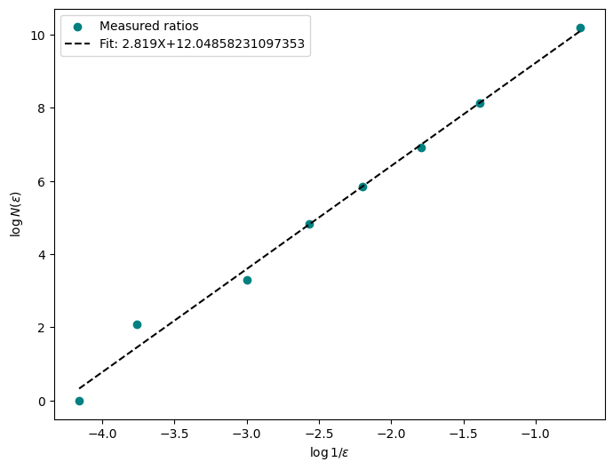

```python
import numpy as np
import matplotlib.pyplot as plt

#test data
box = np.zeros(shape = (100,100,100))
box[20:80,20:80,20:80] = 1



def fractal_dimension(array, max_box_size = None, min_box_size = 1, n_samples = 10, n_offsets = 0, plot = False):
    """Calculates the fractal dimension of a 3D numpy array.

    Args:
        array (np.ndarray): The array to calculate the fractal dimension of.
        max_box_size (int): The largest box size, given as the power of 2 so that
                            2**max_box_size gives the sidelength of the largest box.
        min_box_size (int): The smallest box size, given as the power of 2 so that
                            2**min_box_size gives the sidelength of the smallest box.
                            Default value 1.
        n_samples (int): number of scales to measure over.
        n_offsets (int): number of offsets to search over to find the smallest set N(s) to
                       cover  all voxels>0.


    """
    #determine the scales to measure on
    if max_box_size == None:
        #default max size is the largest power of 2 that fits in the smallest dimension of the array:
        max_box_size = int(np.floor(np.log2(np.min(array.shape))))
    scales = np.floor(np.logspace(max_box_size,min_box_size, num = n_samples, base =2 ))
    scales = np.unique(scales) #remove duplicates that could occur as a result of the floor

    #get the locations of all non-zero pixels
    locs = np.where(array > 0)
    voxels = np.array([(x,y,z) for x,y,z in zip(*locs)])

    #count the minimum amount of boxes touched
    Ns = []
    #loop over all scales
    for scale in scales:
        touched = []
        if n_offsets == 0:
            offsets = [0]
        else:
            offsets = np.linspace(0, scale, n_offsets)
        #search over all offsets
        for offset in offsets:
            bin_edges = [np.arange(0, i, scale) for i in array.shape]
            bin_edges = [np.hstack([0-offset,x + offset]) for x in bin_edges]
            H1, e = np.histogramdd(voxels, bins = bin_edges)
            touched.append(np.sum(H1>0))
        Ns.append(touched)
    Ns = np.array(Ns)

    #From all sets N found, keep the smallest one at each scale
    Ns = Ns.min(axis=1)



    #Only keep scales at which Ns changed
    scales  = np.array([np.min(scales[Ns == x]) for x in np.unique(Ns)])


    Ns = np.unique(Ns)
    Ns = Ns[Ns > 0]
    scales = scales[:len(Ns)]
    #perform fit
    coeffs = np.polyfit(np.log(1/scales), np.log(Ns),1)

    #make plot
    if plot:
        fig, ax = plt.subplots(figsize = (8,6))
        ax.scatter(np.log(1/scales), np.log(np.unique(Ns)), c = "teal", label = "Measured ratios")
        ax.set_ylabel("$\log N(\epsilon)$")
        ax.set_xlabel("$\log 1/ \epsilon$")
        fitted_y_vals = np.polyval(coeffs, np.log(1/scales))
        ax.plot(np.log(1/scales), fitted_y_vals, "k--", label = f"Fit: {np.round(coeffs[0],3)}X+{coeffs[1]}")
        ax.legend();
    return(coeffs[0])



fd = fractal_dimension(box, n_offsets=10, plot = True)
print(f"Fractal Dimension of the box: {fd}")
plt.show()
```

For a more complete overview of the function and its parameters, have a look at the notebook detailing the development of the function in binder.

## Fractal Dimension of the cerebral cortex

```python
import os
import tifffile
from skimage import filters
from skimage import exposure
import ipywidgets as widgets
import nibabel as nib
```

### 1.- Carga la imagen Nifti usando la librería nibabel.

```python
nifti_file_path = 'Pitt_0050028_cortex_mask.nii.gz'

# Cargar la imagen NIfTI
nifti_img = nib.load(nifti_file_path)

# Obtener datos y encabezado
data = nifti_img.get_fdata()
header = nifti_img.header

# Imprimir información básica sobre la imagen
print("Dimensiones de la imagen:", data.shape)
print("Tamaño de píxeles (mm):", header.get_zooms())
```

```
Dimensiones de la imagen: (256, 256, 256)
Tamaño de píxeles (mm): (1.0, 1.0, 1.0)
```

### 2.- Representa la imagen utilizando un deslizador para ver todos los cortes de manera interactiva.

```python
def slice_explorer(image):
    @widgets.interact
    def _slice_explorer(im=widgets.fixed(image), plane=(0,len(image)-1)):
        fig,ax=plt.subplots()

        ax.imshow(im[plane], cmap='gray')
    return _slice_explorer

slice_explorer(data)
```

```
interactive(children=(IntSlider(value=127, description='plane', max=255), Output()), _dom_classes=('widget-int…
```

```
<function __main__.slice_explorer.<locals>._slice_explorer(im=<ipywidgets.widgets.interaction.fixed object at 0x00000220C69C2020>, plane=(0, 255))>
```

### 3.- Calcula la dimensión fractal

```python
fractal_dimension(data)
```

```
2.5751365548097396
```

### 4.- ¿Qué significa el hiperparámetro n_samples y qué efecto tiene?

Él n_samples es el número de escalas que se utilizarán para medir. Cuanto mayor sea, más preciso será el resultado.

Varía este parámetro entre 5 y 50 y representa en un gráfico la dimensión fractal vs n_samples. ¿Qué valor escogerías?

```python
rangos=range(5,50)
lista=[]
for i in rangos:
    lista.append(fractal_dimension(data, n_samples=i))
```

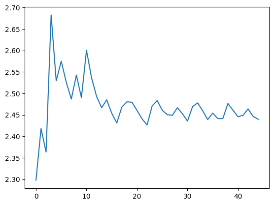

```python
plt.plot(lista)
```

En el gráfico vemos cómo converge entorno al 2.40-2.50, para tomar un valor más preciso, voy a hacer la media de los últimos 10 valores:

```python
np.mean(lista[-10:])
```

```
2.451894192943258
```

Así, la dimensión será más o menos 2.45